# Bulk RNA-Seq Analysis

Daniele Colombo

2021-07-29

# Introduction

In this report, a bulk-RNA seq analysis is described comparing samples from brain, heart and colon. Three samples from each tissue are retrieved from a bigger dataset and, once preprocessed, they are used in order to find differentially expressed genes that characterize one tissue with respect to the other ones.

## Used packages

The main steps for bulk RNA-Seq analysis are performed with the `edgeR` package. For plotting, `ggplot2` is used and the package `SummarizedExperiments` is used to store and perform some operations on the data (together with `recount`):

```r
library("edgeR")
library("ggplot2")
library("SummarizedExperiment")
library("recount")
```

# Data loading and preprocessing

The data used for this analysis is contained inside of bigger datasets which consists of 10 samples from each tissue. Each of the dataset is a RangedSummarizedExperiment object, containing a count matrix and some metadata for each row (gene) and for each column (sample).

Once loaded the datasets for each tissue are preprocessed separately with an ad hoc function, such that the following operations are performed:

- Only the wanted columns are kept
- Only genes longer than 200 bp are kept
- Mitochondrial genes are removed

The output of this function would be for each dataset a list containing the filtered dataset and some pre-processing statistics:

- The filtered RangedSummarizedExperiment
- The total number of reads for each sample
- The number of short reads (shorter than 200 bp) for each sample
- The percentage of short reads for each sample
- The number of mitochondrial reads for each sample
- The percentage of mitochondrial reads for each sample

```r
preprocess <- function(dataset_name, columns) {

    # Load the dataset and select the columns
    dataset <- get(load(dataset_name))
    dataset <- dataset[, columns]

    # Set the conditions for filtering
    length_condition <- dataset@rowRanges$bp_length >= 200
    # chrM_condition <- !(sapply(sapply(rowData(dataset)$symbol, grepl,
    # pattern='^MT-*'), any))
    chrM_condition <- as.vector(seqnames(dataset@rowRanges) != "chrM")

    # Get the count table and compute results from filtering
    count_table <- assays(dataset)[[1]]
    total_reads <- colSums(count_table)

    # Count short reads
    short_reads <- colSums(count_table[!length_condition, ])
    short_reads_perc <- (short_reads/total_reads) * 100

    # Count reads on mt genes
    mt_reads <- colSums(count_table[!chrM_condition & length_condition, ])
    mt_reads_perc <- (mt_reads/total_reads) * 100

    # Filter the dataset
    dataset <- dataset[length_condition & chrM_condition, ]

    # Return a list with the processed dataset and the results from filtering
    result = list(dataset = dataset, total_reads = total_reads, short_reads = short_reads,
        short_reads_perc = short_reads_perc, mt_reads = mt_reads, mt_reads_perc = mt_reads_perc)
    return(result)
}
```

The function is then used to preprocess the datasets that are stored locally:

```r
# Preprocess brain
brain_preprocessed <- preprocess("rse_gene_brain_9_scaled.Rdata", c(8, 9, 10))

# Preprocess heart
heart_preprocessed <- preprocess("rse_gene_heart_6_scaled.Rdata", c(2, 3, 4))

# Preprocess colon
colon_preprocessed <- preprocess("rse_gene_colon_5_scaled.Rdata", c(1, 2, 3))
```

The following are the resulting pre-processing statistics:

```r
brain_tab <- vapply(brain_preprocessed[2:6], unlist, numeric(3))
heart_tab <- vapply(heart_preprocessed[2:6], unlist, numeric(3))
colon_tab <- vapply(colon_preprocessed[2:6], unlist, numeric(3))

tab <- as.data.frame(rbind(brain_tab, heart_tab, colon_tab))
tab
```

|  | total_reads | short_reads | short_reads_perc | mt_reads | mt_reads_perc |
| --- | --- | --- | --- | --- | --- |
| SRR1337909 | 38280901 | 106875 | 0.2791862 | 12182513 | 31.823998 |
| SRR1397094 | 36625433 | 69732 | 0.1903923 | 6395981 | 17.463223 |
| SRR817686 | 37946538 | 58186 | 0.1533368 | 2952326 | 7.780225 |
| SRR1468613 | 39229440 | 121991 | 0.3109680 | 14936858 | 38.075634 |
| SRR815184 | 37043909 | 59684 | 0.1611169 | 6376484 | 17.213313 |
| SRR1381693 | 39624745 | 116328 | 0.2935741 | 13635931 | 34.412666 |
| SRR1073217 | 37414767 | 143096 | 0.3824586 | 5877170 | 15.708156 |
| SRR1330831 | 38316951 | 72061 | 0.1880656 | 4417819 | 11.529673 |
| SRR1456250 | 36188295 | 68784 | 0.1900725 | 2128143 | 5.880750 |

The three filtered datasets are then stored in a single RangedSummarizedExperiment object in order to perform the analysis and the count table is extracted:

```r
merged_dataset <- cbind(brain_preprocessed$dataset, heart_preprocessed$dataset, colon_preprocessed$dataset)
count_table <- assays(merged_dataset)[[1]]
head(count_table)
```

```
                   SRR1337909 SRR1397094 SRR817686 SRR1468613 SRR815184
ENSG00000000003.14        485        500       234        179       412
ENSG00000000005.5           8          1         1          5         1
ENSG00000000419.12        319        584       511        574       534
ENSG00000000457.13        297        332       461        263       334
ENSG00000000460.16        138        187       412        124       213
ENSG00000000938.12        146        241       837        281       834
                   SRR1381693 SRR1073217 SRR1330831 SRR1456250
ENSG00000000003.14        133       3175        406        871
ENSG00000000005.5           1         25         15          2
ENSG00000000419.12        490        793        636        869
ENSG00000000457.13        218        760        664        583
ENSG00000000460.16         99        380        289        353
ENSG00000000938.12        146        500        982        627
```

# DE genes analysis with edgeR

To start the bulk RNA-Seq analysis, the count table needs to be converted into a DGEList object, which contains all the data stored in a better way for usage with edgeR and allows to subsequently add further data derived from the following steps of the analysis itself:

```r
DGE <- DGEList(counts = count_table)
paste("Number of genes:", dim(DGE$counts)[1])
```

```
[1] "Number of genes: 50681"
```

The first data to add to the DGEList is the definition of groups in which the samples can be divided. In this case, the groups are defined by the tissues:

```r
group <- as.factor(rep(c("brain", "heart", "colon"), each = 3))
DGE$samples$group <- group
```

The resulting DGEList is the starting point for the bulk analysis:

```
An object of class "DGEList"
$counts
                   SRR1337909 SRR1397094 SRR817686 SRR1468613 SRR815184
ENSG00000000003.14        485        500       234        179       412
ENSG00000000005.5           8          1         1          5         1
ENSG00000000419.12        319        584       511        574       534
ENSG00000000457.13        297        332       461        263       334
ENSG00000000460.16        138        187       412        124       213
ENSG00000000938.12        146        241       837        281       834
                   SRR1381693 SRR1073217 SRR1330831 SRR1456250
ENSG00000000003.14        133       3175        406        871
ENSG00000000005.5           1         25         15          2
ENSG00000000419.12        490        793        636        869
ENSG00000000457.13        218        760        664        583
ENSG00000000460.16         99        380        289        353
ENSG00000000938.12        146        500        982        627

$samples
           group lib.size norm.factors
SRR1337909 brain 25991513            1
SRR1397094 brain 30159720            1
SRR817686  brain 34936026            1
SRR1468613 heart 24170591            1
SRR815184  heart 30607741            1
SRR1381693 heart 25872486            1
SRR1073217 colon 31394501            1
SRR1330831 colon 33827071            1
SRR1456250 colon 33991368            1
```

## Genes filtering

In order to remove genes with counts that are overall low or equal to 0, the following function from `edgeR` is used with default parameters:

```r
keep_exprs <- filterByExpr(DGE, group = group)
DGE <- DGE[keep_exprs, , keep.lib.sizes = FALSE]
paste("Number of discarded genes:", sum(!keep_exprs))
```

```
[1] "Number of discarded genes: 26271"
```

```r
paste("Number of retained genes:", sum(keep_exprs))
```

```
[1] "Number of retained genes: 24410"
```

## Data normalization and logCPM computation

After filtering genes, the data is normalized with the default edgeR method, which is TMM, that uses for normalization a trimmed scaling factor for each column (sample). The read counts are then stored as the logarithm of the Counts Per Million (CPM):

```r
logcpm_before <- cpm(DGE, log = TRUE)  # store the cpm values before TMM normalization
DGE <- calcNormFactors(DGE, method = "TMM")
logcpm <- cpm(DGE, log = TRUE)
DGE$samples  # Samples with their scaling factor
```

|  | group | lib.size | norm.factors |
| --- | --- | --- | --- |
| SRR1337909 | brain | 25907145 | 1.0938067 |
| SRR1397094 | brain | 30027560 | 1.2098355 |
| SRR817686 | brain | 34887615 | 0.9886989 |
| SRR1468613 | heart | 24150483 | 0.8254019 |
| SRR815184 | heart | 30557611 | 1.0196125 |
| SRR1381693 | heart | 25854471 | 0.6900722 |
| SRR1073217 | colon | 30797509 | 1.2010008 |
| SRR1330831 | colon | 33785627 | 1.0138984 |
| SRR1456250 | colon | 33945914 | 1.0807772 |

With the following boxplots, we can observe the distribution of the log(CPM) in each sample before and after the normalization:

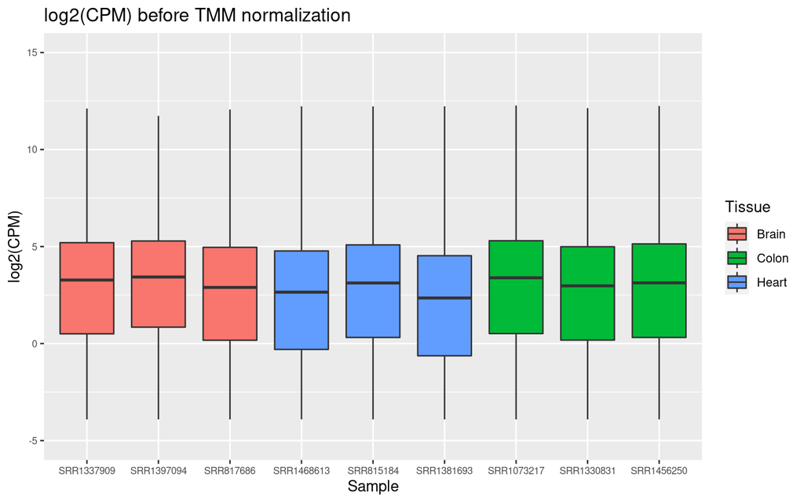

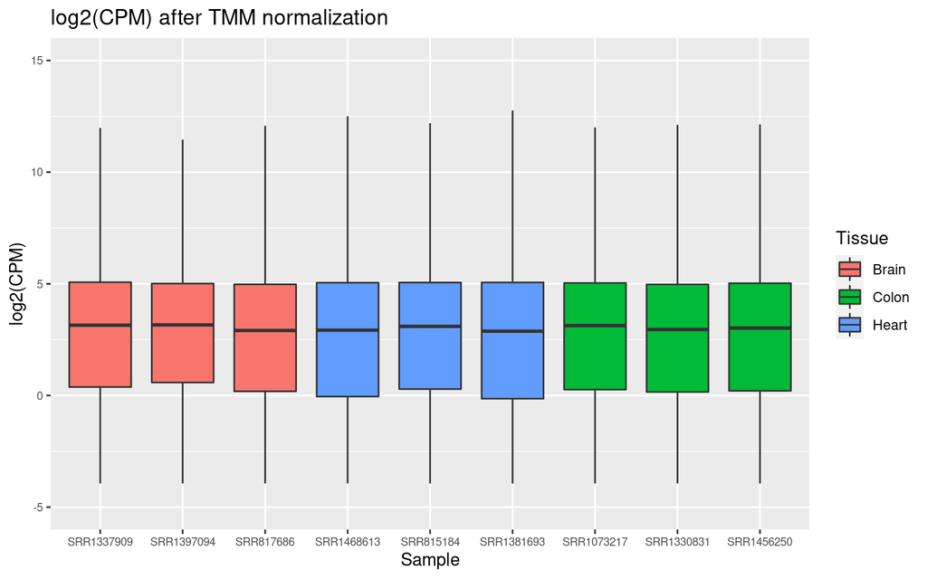

```r
# Reshape the datasets for logcpm vertically
logcpm_before_plot <- reshape2::melt(logcpm_before)
logcpm_before_plot$Tissue <- rep(c("Brain", "Heart", "Colon"), each = sum(logcpm_before_plot$Var2 ==
    logcpm_before_plot$Var2[1]) * 3)

logcpm_plot <- reshape2::melt(logcpm)
logcpm_plot$Tissue <- rep(c("Brain", "Heart", "Colon"), each = sum(logcpm_plot$Var2 ==
    logcpm_plot$Var2[1]) * 3)

# Plot the distributions
ggplot(data = logcpm_before_plot, aes(x = Var2, y = value, fill = Tissue)) + geom_boxplot(outlier.shape = NA) +
    ylim(-5, 15) + ylab("log2(CPM)") + xlab("Sample") + ggtitle("log2(CPM) before TMM normalization") +
    theme(axis.text = element_text(size = 7))
ggplot(data = logcpm_plot, aes(x = Var2, y = value, fill = Tissue)) + geom_boxplot(outlier.shape = NA) +
    ylim(-5, 15) + ylab("log2(CPM)") + xlab("Sample") + ggtitle("log2(CPM) after TMM normalization") +
    theme(axis.text = element_text(size = 7))
```

As can be seen from the two plots, the distribution of the log2(CPM) along the different samples is more or less the same after the normalization. The change given by the scaling factors is not drastical, but can nevertheless be seen.

## Linear model design

Since different tissues are compared and there isn’t a reference condition to compare to other ones, no intercept is used in the linear model. The features used in the linear model are the tissue to which the samples come from, which will be selected in alphabetical order, i.e. brain, colon and heart:

```r
design <- model.matrix(~0 + group, data = DGE$samples)
colnames(design) <- levels(DGE$samples$group)
design
```

```
           brain colon heart
SRR1337909     1     0     0
SRR1397094     1     0     0
SRR817686      1     0     0
SRR1468613     0     0     1
SRR815184      0     0     1
SRR1381693     0     0     1
SRR1073217     0     1     0
SRR1330831     0     1     0
SRR1456250     0     1     0
attr(,"assign")
[1] 1 1 1
attr(,"contrasts")
attr(,"contrasts")$group
[1] "contr.treatment"
```

## Exploratory analysis

In order to evaluate the similarity between the different samples used for each tissue, they can be plotted in a two-dimensional space such that their distance in the plot approximates their expression difference. This is done through dimensionality reduction of gene expression, and the two main methods that can be used are Multidimensional Scaling (MDS) and Principal Components Analysis (PCA):

### MDS plot

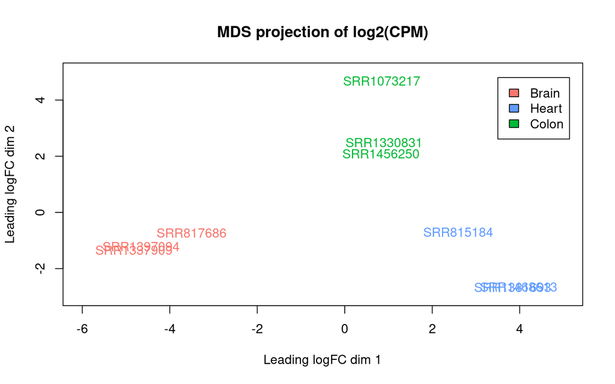

```r
ggplot_col <- c("#F8766D", "#619CFF", "#00BA38")  # store standard ggplot colors

# Plot with MDS
plotMDS(logcpm, labels = colnames(logcpm), main = "MDS projection of log2(CPM)",
    col = rep(ggplot_col, each = 3), xlim = c(-6, 5), ylim = c(-3, 5))
legend(3.5, 4.8, legend = c("Brain", "Heart", "Colon"), fill = ggplot_col)
```

As can be seen, the samples of each tissue are quite similar to each other and cluster well together.

### PCA plot

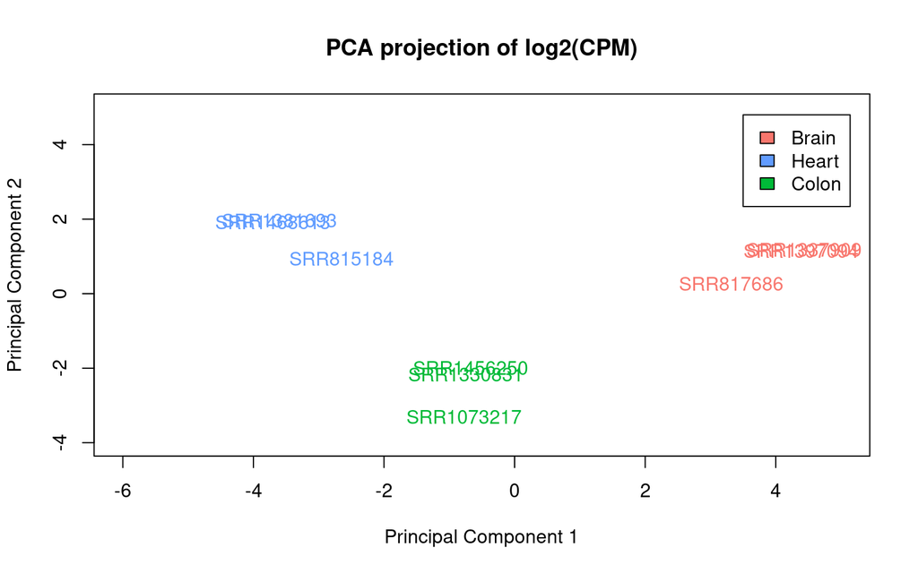

```r
# Plot with PCA
ggplot_col <- c("#F8766D", "#619CFF", "#00BA38")  # store standard ggplot colors

plotMDS(logcpm, labels = colnames(logcpm), main = "PCA projection of log2(CPM)",
    gene.selection = "common", col = rep(ggplot_col, each = 3), xlim = c(-6, 5),
    ylim = c(-4, 5))
legend(3.5, 4.8, legend = c("Brain", "Heart", "Colon"), fill = ggplot_col)
```

As can be seen, the samples of each tissue are quite similar to each other and cluster well together.

In order to fit the model used by edgeR it’s necessary to evaluate if the normalized counts can be modeled with a Negative Binomial distribution, which is used by edgeR itself to model the variability of counts. In order to do that, the following plot is produced showing as estimate for the dispersion of the NB the Biological Coefficient of Variation (BCV):

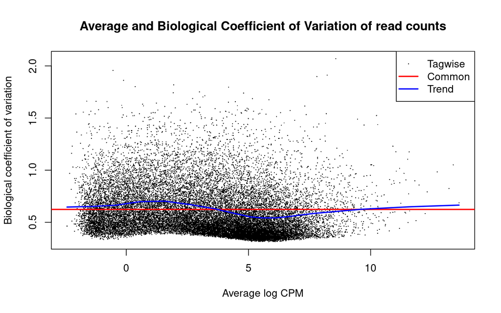

```r
DGE <- estimateDisp(DGE, design)
plotBCV(DGE, main = "Average and Biological Coefficient of Variation of read counts")
```

The datasets have the following common dispersion estimate, which is reasonable:

```r
DGE$common.dispersion
```

```
[1] 0.3885556
```

## Model fitting

With the next command, edgeR performs parameters estimation for the fitting of the negative binomial distribution on the counts:

```r
fit <- glmQLFit(DGE, design)
```

## DE genes

With the following code, the comparisons made between tissues are:

- Brain versus colon
- Brain versus heart
- Colon versus heart

### Brain versus colon

```r
# 1vs2: brain versus colon
qlf.1vs2 <- glmQLFTest(fit, contrast = c(1, -1, 0))

# select the significant ones, with corrected p-value (FDR) < 0.05: colon
# versus brain
FDR.1vs2 <- p.adjust(qlf.1vs2$table$PValue, method = "BH")
summary(decideTests(qlf.1vs2, p.value = 0.05))
```

```
       1*brain -1*colon
Down               2130
NotSig            19939
Up                 2341
```

```r
# Filter table by FDR and store up and down regulated genes
deg.1vs2 <- topTags(qlf.1vs2, n = 20000, adjust.method = "BH", sort.by = "PValue",
    p.value = 0.05)$table
up.genes.1vs2 <- row.names(deg.1vs2[deg.1vs2$logFC > 0, ])
down.genes.1vs2 <- row.names(deg.1vs2[deg.1vs2$logFC < 0, ])
deg.1vs2
```

|  | logFC | logCPM | F | PValue | FDR |
| --- | --- | --- | --- | --- | --- |
| ENSG00000184486.9 | 8.1686428 | 3.369485e+00 | 233.22345 | 1.096775e-07 | 0.001396910 |
| ENSG00000074211.13 | 8.1969875 | 6.568108e+00 | 230.92191 | 1.144539e-07 | 0.001396910 |
| ENSG00000165478.6 | 7.4527053 | 6.452051e+00 | 204.85239 | 1.913131e-07 | 0.001556651 |
| ENSG00000115266.11 | 5.3113199 | 6.259994e+00 | 187.57613 | 2.787456e-07 | 0.001568126 |
| ENSG00000221932.6 | 7.3747907 | 5.798702e+00 | 181.34120 | 3.219380e-07 | 0.001568126 |
| ENSG00000120251.18 | 9.1742890 | 5.776003e+00 | 173.20688 | 3.913517e-07 | 0.001568126 |
| ENSG00000162728.4 | 10.0688802 | 5.940248e+00 | 162.09613 | 5.185076e-07 | 0.001568126 |
| ENSG00000084710.13 | 5.0899280 | 5.680383e+00 | 160.79049 | 5.365803e-07 | 0.001568126 |
| ENSG00000183166.10 | 10.2948320 | 5.035842e+00 | 154.03649 | 6.434159e-07 | 0.001568126 |
| ENSG00000170323.8 | -7.7208676 | 5.950905e+00 | 153.65782 | 6.501444e-07 | 0.001568126 |

[output cut: 4461 more lines]

### Brain versus heart

```r
# 1vs3: brain versus heart
qlf.1vs3 <- glmQLFTest(fit, contrast = c(1, 0, -1))

# select the significant ones, with corrected p-value (FDR) < 0.05: heart
# versus brain
FDR.1vs3 <- p.adjust(qlf.1vs3$table$PValue, method = "BH")
summary(decideTests(qlf.1vs3, p.value = 0.05))
```

```
       1*brain -1*heart
Down               2040
NotSig            19867
Up                 2503
```

```r
# Filter table by FDR and store up and down regulated genes
deg.1vs3 <- topTags(qlf.1vs3, n = 20000, adjust.method = "BH", sort.by = "PValue",
    p.value = 0.05)$table
up.genes.1vs3 <- row.names(deg.1vs3[deg.1vs3$logFC > 0, ])
down.genes.1vs3 <- row.names(deg.1vs3[deg.1vs3$logFC < 0, ])
deg.1vs3
```

|  | logFC | logCPM | F | PValue | FDR |
| --- | --- | --- | --- | --- | --- |
| ENSG00000183072.9 | -11.8912721 | 6.119724755 | 329.19652 | 2.473400e-08 | 0.0003996751 |
| ENSG00000089225.19 | -10.7253157 | 4.937959151 | 305.81256 | 3.404776e-08 | 0.0003996751 |
| ENSG00000165478.6 | 9.5006096 | 6.452051466 | 273.72405 | 5.500453e-08 | 0.0003996751 |
| ENSG00000115266.11 | 6.4830147 | 6.259993825 | 248.88208 | 8.292071e-08 | 0.0003996751 |
| ENSG00000158022.6 | -11.1001995 | 6.400304250 | 240.08344 | 9.682027e-08 | 0.0003996751 |
| ENSG00000221932.6 | 9.4052733 | 5.798701555 | 239.27231 | 9.824051e-08 | 0.0003996751 |
| ENSG00000184486.9 | 7.6914428 | 3.369485060 | 211.75213 | 1.660124e-07 | 0.0005789091 |
| ENSG00000168334.8 | -12.7049759 | 8.214434153 | 199.71060 | 2.132875e-07 | 0.0005960765 |
| ENSG00000198914.3 | 9.8168705 | 4.836851021 | 198.14102 | 2.206039e-07 | 0.0005960765 |
| ENSG00000141161.11 | -12.3102297 | 6.525830037 | 193.48450 | 2.441936e-07 | 0.0005960765 |

[output cut: 4533 more lines]

### Colon versus heart

```r
# 2vs3: colon versus heart
qlf.2vs3 <- glmQLFTest(fit, contrast = c(0, 1, -1))

# select the significant ones, with corrected p-value (FDR) < 0.05: heart
# versus colon
FDR.2vs3 <- p.adjust(qlf.2vs3$table$PValue, method = "BH")
summary(decideTests(qlf.2vs3, p.value = 0.05))
```

```
       1*colon -1*heart
Down                324
NotSig            24006
Up                   80
```

```r
# Filter table by FDR and store up and down regulated genes
deg.2vs3 <- topTags(qlf.2vs3, n = 20000, adjust.method = "BH", sort.by = "PValue",
    p.value = 0.05)$table
up.genes.2vs3 <- row.names(deg.2vs3[deg.2vs3$logFC > 0, ])
down.genes.2vs3 <- row.names(deg.2vs3[deg.2vs3$logFC < 0, ])
deg.2vs3
```

|  | logFC | logCPM | F | PValue | FDR |
| --- | --- | --- | --- | --- | --- |
| ENSG00000183072.9 | -11.228782 | 6.11972475 | 315.84633 | 2.960112e-08 | 0.0005831354 |
| ENSG00000089225.19 | -9.769259 | 4.93795915 | 282.79013 | 4.777841e-08 | 0.0005831354 |
| ENSG00000164708.5 | -6.758565 | 7.34291545 | 194.95140 | 2.364428e-07 | 0.0015080448 |
| ENSG00000239775.1 | -6.306156 | 6.79760431 | 192.45026 | 2.498458e-07 | 0.0015080448 |
| ENSG00000156885.5 | -10.504381 | 7.50212415 | 166.33840 | 4.647131e-07 | 0.0015080448 |
| ENSG00000277543.1 | -10.262073 | 5.57022310 | 163.69206 | 4.974181e-07 | 0.0015080448 |
| ENSG00000141161.11 | -10.257719 | 6.52583004 | 163.54391 | 4.993310e-07 | 0.0015080448 |
| ENSG00000158022.6 | -7.918053 | 6.40030425 | 163.29453 | 5.025714e-07 | 0.0015080448 |
| ENSG00000168334.8 | -10.252555 | 8.21443415 | 157.88537 | 5.796420e-07 | 0.0015080448 |
| ENSG00000186439.12 | -8.538790 | 6.51473479 | 155.52392 | 6.177980e-07 | 0.0015080448 |

[output cut: 394 more lines]

The genes significantly up and down regulated for each tissue are then retrieved by intersecting the two comparisons performed for each tissue with respect to the other two:

```r
# Brain (tissue 1)
up.brain <- intersect(up.genes.1vs2, up.genes.1vs3)
down.brain <- intersect(down.genes.1vs2, down.genes.1vs3)

# Colon (tissue 2)
up.colon <- intersect(up.genes.2vs3, down.genes.1vs2)
down.colon <- intersect(down.genes.2vs3, up.genes.1vs2)

# Heart (tissue 3)
up.heart <- intersect(down.genes.1vs3, down.genes.2vs3)
down.heart <- intersect(up.genes.1vs3, up.genes.2vs3)
```

# Saving data to .xlsx file

In order to share the data in a more easily readable format, the data retrieved is stored in an excel spreadsheet, with different sheets containing:

1. Up and down regulated genes of brain with respect to colon
2. Up and down regulated genes of brain with respect to heart
3. Up and down regulated genes of colon with respect to heart
4. Up and down regulated genes of brain with respect to the other two tissues
5. Up and down regulated genes of colon with respect to the other two tissues
6. Up and down regulated genes of heart with respect to the other two tissues

Firstly, the gene names are stored in a properly formatted dataset containing up and down regulated genes in two columns with the following function:

```r
de.genes.dataframe <- function(col1, col2, column.names) {
    de.genes <- data.frame(col1 = rep(NA, max(sapply(list(col1, col2), length))))
    de.genes[1:length(col1), 1] <- col1
    de.genes[1:length(col2), 2] <- col2
    colnames(de.genes) <- column.names

    return(de.genes)
}


comparison.1vs2 <- de.genes.dataframe(up.genes.1vs2, down.genes.1vs2, c("up.brain.vs.colon",
    "down.brain.vs.colon"))
comparison.1vs3 <- de.genes.dataframe(up.genes.1vs3, down.genes.1vs3, c("up.brain.vs.heart",
    "down.brain.vs.heart"))
comparison.2vs3 <- de.genes.dataframe(up.genes.2vs3, down.genes.2vs3, c("up.colon.vs.heart",
    "down.colon.vs.heart"))
de.genes.brain <- de.genes.dataframe(up.brain, down.brain, c("up.brain", "down.brain"))
de.genes.colon <- de.genes.dataframe(up.colon, down.colon, c("up.colon", "down.colon"))
de.genes.heart <- de.genes.dataframe(up.heart, down.heart, c("up.heart", "down.heart"))
```

The dataframes are then stored in the .xlsx file with the function provided by the package `xlsx`:

```r
xlsx::write.xlsx(comparison.1vs2, "DE_genes.xlsx", sheetName = "Tissue 1 vs 2", col.names = TRUE,
    row.names = FALSE, append = FALSE, showNA = FALSE)
xlsx::write.xlsx(comparison.1vs3, "DE_genes.xlsx", sheetName = "Tissue 1 vs 3", col.names = TRUE,
    row.names = FALSE, append = TRUE, showNA = FALSE)
xlsx::write.xlsx(comparison.2vs3, "DE_genes.xlsx", sheetName = "Tissue 2 vs 3", col.names = TRUE,
    row.names = FALSE, append = TRUE, showNA = FALSE)
xlsx::write.xlsx(de.genes.brain, "DE_genes.xlsx", sheetName = "DE genes tissue 1",
    col.names = TRUE, row.names = FALSE, append = TRUE, showNA = FALSE)
xlsx::write.xlsx(de.genes.colon, "DE_genes.xlsx", sheetName = "DE genes tissue 2",
    col.names = TRUE, row.names = FALSE, append = TRUE, showNA = FALSE)
xlsx::write.xlsx(de.genes.heart, "DE_genes.xlsx", sheetName = "DE genes tissue 3",
    col.names = TRUE, row.names = FALSE, append = TRUE, showNA = FALSE)
```

# Functional Enrichment Analysis

In order to perform functional enrichment for this analysis, [Enrichr](https://maayanlab.cloud/Enrichr/) was used. Since it accepts only gene symbols as search input, the ensembl gene IDs stored in the RangedSummarizedExperiments need to be converted. The function `mapIds` from the package `AnnotationDbi` is used for this task and in case of mapping of one ensembl ID to multiple gene symbols the first symbol is used. For this conversion to work, the version of the ensembl ID is removed with `gsub`. Finally, the gene symbols are stored in a .txt file:

```r
write.gene.symbols <- function(ensembl, file.name) {
    symbols <- mapIds(org.Hs.eg.db, keys = gsub("\\..*", "", ensembl), keytype = "ENSEMBL",
        column = "SYMBOL", multiVals = "first")
    write.table(symbols[!is.na(symbols)], file.name, col.names = F, row.names = F,
        quote = F)
}

write.gene.symbols(up.brain, "up_brain_symbols.txt")
write.gene.symbols(up.colon, "up_colon_symbols.txt")
write.gene.symbols(up.heart, "up_heart_symbols.txt")
```